# B cells

cytoplasmic projects:

- old B cells: PXD006570
- young B cells:PXD006572

nuclear proteins:

- old B cells:PXD006571
- young B cells:PXD006576

there were 3 young donors and 3 elderly donors

# Chaperones

Chaperones are part of the proteostasis network. Looking for more modifications in chaperones in ageing samples. This would indicate that damage of the proteostasis network is a feature of ageing.

Not significant for both nuc and cyto.

General comparison of the number of modifications. Sum cytoplasm and nuclear (complete)

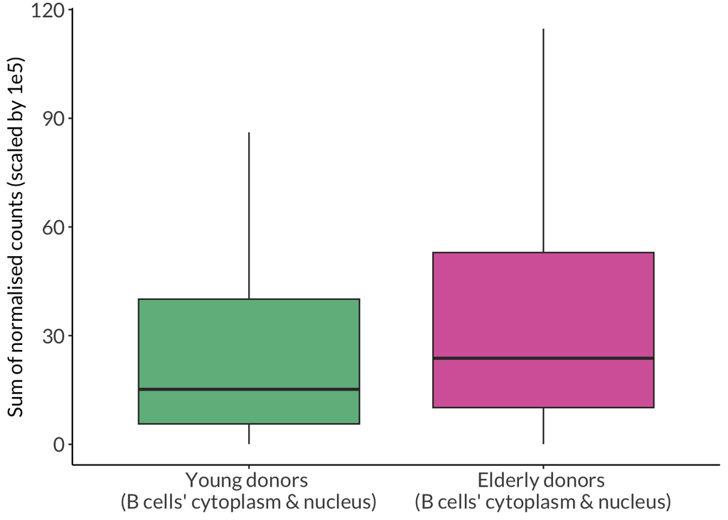

```
    Wilcoxon rank sum test with continuity correction

data:  df1$sum and df2$sum
W = 2641.5, p-value = 0.09612
alternative hypothesis: true location shift is not equal to 0
```

```
[1] "young"
```

```
[1] 79
```

```
[1] "old"
```

```
[1] 79
```

Only the PTMs.

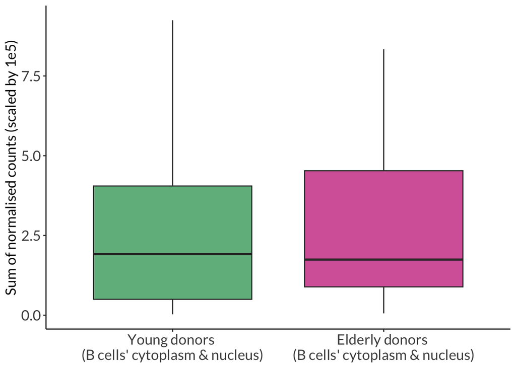

```
    Wilcoxon rank sum test with continuity correction

data:  df1$sum and df2$sum
W = 389.5, p-value = 0.9739
alternative hypothesis: true location shift is not equal to 0
```

```
[1] "young"
```

```
[1] 28
```

```
[1] "old"
```

```
[1] 28
```

# Initial modifications

## Phosphorylation - not enough

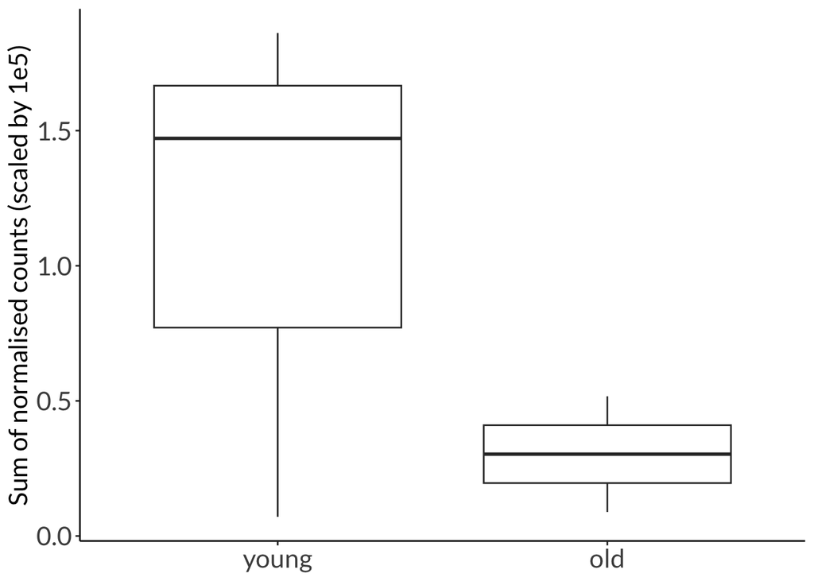

```
[1] "young"
```

```
[1] 3
```

```
[1] "old"
```

```
[1] 2
```

```
    Wilcoxon rank sum exact test

data:  df1$sum and df2$sum
W = 4, p-value = 0.8
alternative hypothesis: true location shift is not equal to 0
```

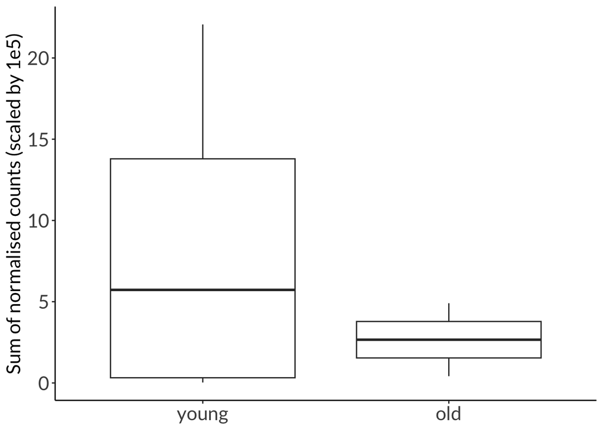

```
[1] "young"
```

```
[1] 4
```

```
[1] "old"
```

```
[1] 2
```

```
    Wilcoxon rank sum test with continuity correction

data:  df1$sum and df2$sum
W = 4.5, p-value = 1
alternative hypothesis: true location shift is not equal to 0
```

## Acetylation - not enough

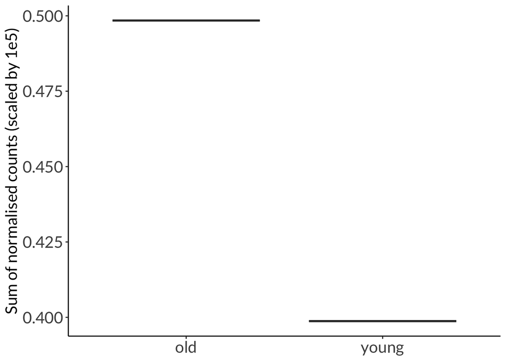

```
[1] "young"
```

```
[1] 1
```

```
[1] "old"
```

```
[1] 1
```

```
    Wilcoxon rank sum exact test

data:  df1$sum and df2$sum
W = 0, p-value = 1
alternative hypothesis: true location shift is not equal to 0
```

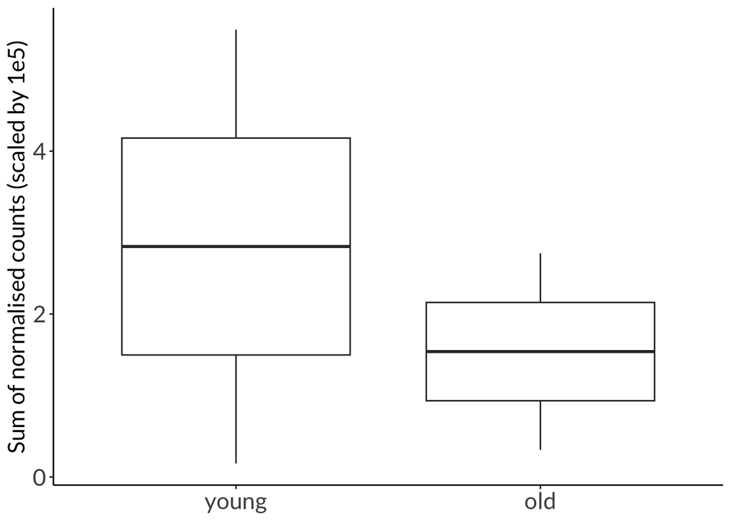

```
[1] "young"
```

```
[1] 2
```

```
[1] "old"
```

```
[1] 2
```

```
    Wilcoxon rank sum exact test

data:  df1$sum and df2$sum
W = 2, p-value = 1
alternative hypothesis: true location shift is not equal to 0
```

## Methylation - not enough

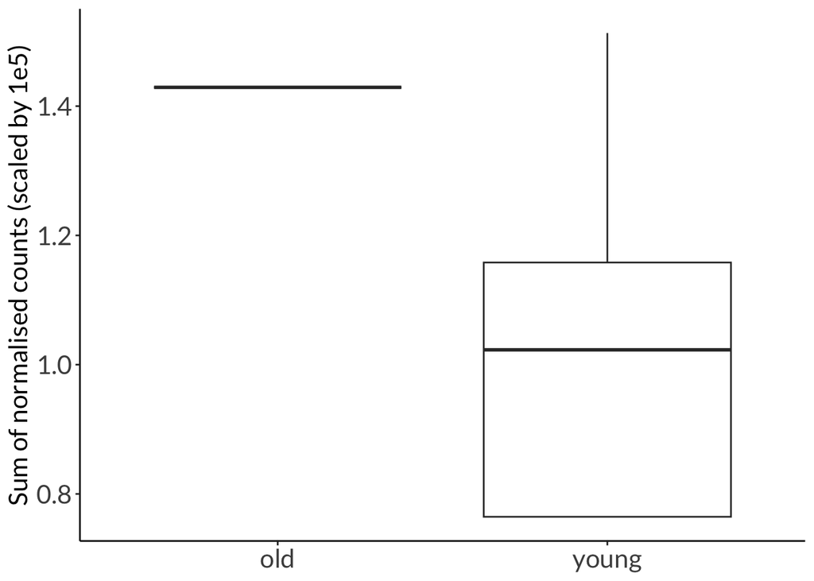

```
[1] "young"
```

```
[1] 4
```

```
[1] "old"
```

```
[1] 1
```

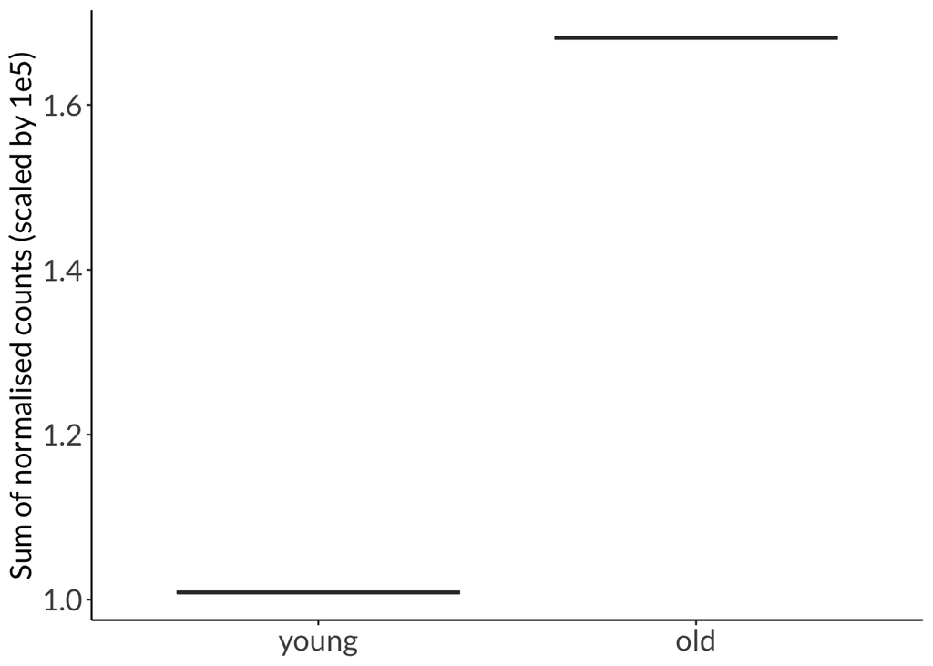

```
[1] "young"
```

```
[1] 1
```

```
[1] "old"
```

```
[1] 1
```

## oxPTMs

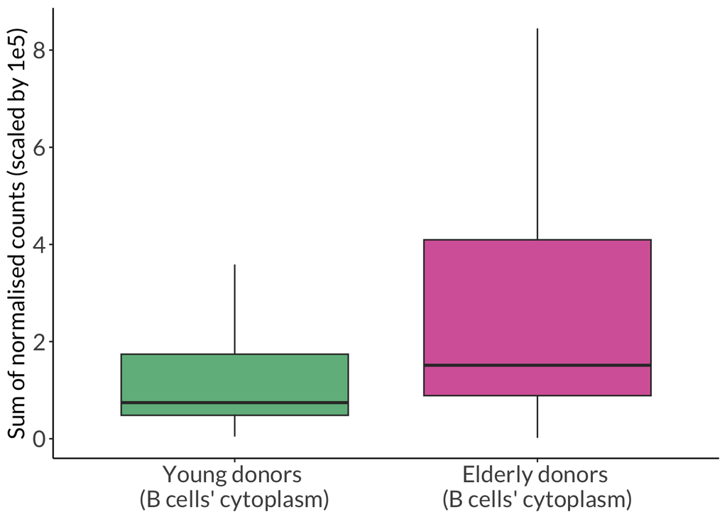

```
[1] "young"
```

```
[1] 23
```

```
[1] "old"
```

```
[1] 23
```

```
    Wilcoxon rank sum exact test

data:  df1$sum and df2$sum
W = 170, p-value = 0.03806
alternative hypothesis: true location shift is not equal to 0
```

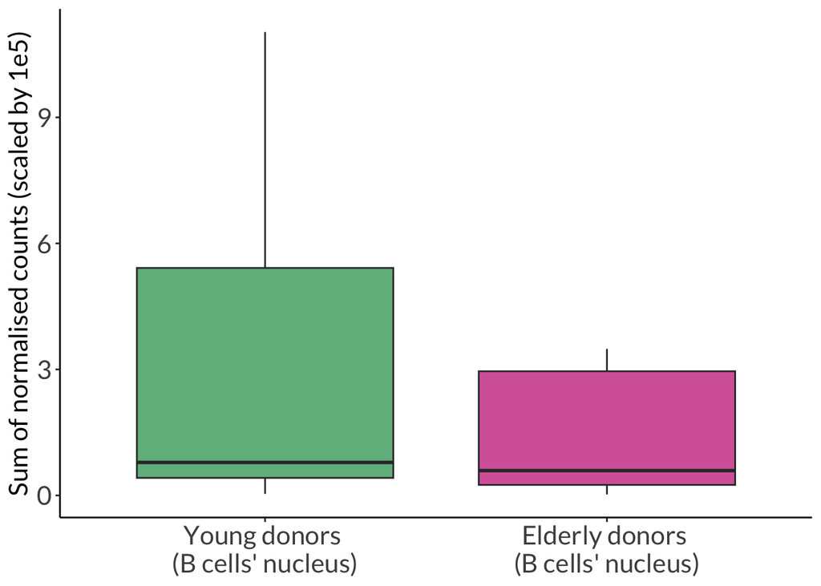

```
[1] "young"
```

```
[1] 16
```

```
[1] "old"
```

```
[1] 16
```

```
    Wilcoxon rank sum test with continuity correction

data:  df1$sum and df2$sum
W = 144.5, p-value = 0.5465
alternative hypothesis: true location shift is not equal to 0
```

## K acylation - NO

NOT FOUND

## AGEs - NO

NOT FOUND

## Ubiquitination - not enough

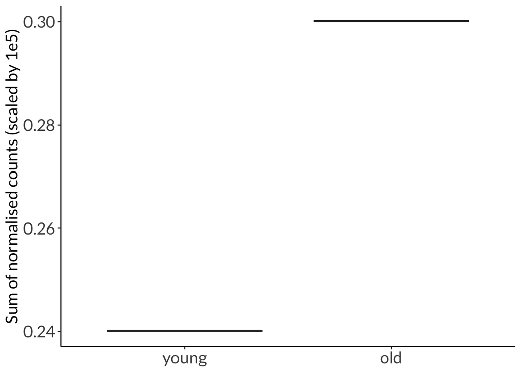

```
[1] "young"
```

```
[1] 1
```

```
[1] "old"
```

```
[1] 1
```

[figure not shown]

The previously selected modifications do not work. Are there any modification enrichments here at all?

# Fold change

In which **chaperones** was there an increase or decrease in PTMs? This is using the fold change >2 or < 0.5

First the cytoplasm:

Chaperones in which PTMs increased (cytoplasm)

| Uniprot_entry_name | sum_young | sum_old | change |
| --- | --- | --- | --- |
| HS90B_HUMAN | 2.00e-07 | 2.50e-06 | 16.666667 |
| CH60_HUMAN | 9.00e-07 | 7.30e-06 | 8.333333 |
| CDC37_HUMAN | 3.00e-06 | 1.74e-05 | 5.833333 |
| DNJC8_HUMAN | 3.34e-05 | 8.34e-05 | 2.500000 |
| CALX_HUMAN | 7.00e-07 | 1.50e-06 | 2.083333 |

Chaperones in which PTMs decreased (cytoplasm)

| Uniprot_entry_name | sum_young | sum_old | change |
| --- | --- | --- | --- |
| HSPB1_HUMAN | 2.17e-05 | 5.2e-06 | 0.2380952 |
| TCPH_HUMAN | 4.90e-06 | 6.0e-07 | 0.1190476 |

Now the nucleus:

Chaperones in which PTMs increased (nucleus)

| Uniprot_entry_name | sum_young | sum_old | change |
| --- | --- | --- | --- |
| CWC27_HUMAN | 3.83e-05 | 0.0001148 | 3 |

Chaperones in which PTMs decreased (nucleus)

| Uniprot_entry_name | sum_young | sum_old | change |
| --- | --- | --- | --- |
| PPIG_HUMAN | 0.0000335 | 1.26e-05 | 0.3750000 |
| FKB15_HUMAN | 0.0002820 | 6.74e-05 | 0.2391304 |
| CTR9_HUMAN | 0.0003971 | 4.41e-05 | 0.1111111 |

Nuclear (young)

| Uniprot_entry_name |
| --- |
| AIP_HUMAN |
| ATD3B_HUMAN |
| BAG2_HUMAN |
| BAG4_HUMAN |
| BAG5_HUMAN |
| CALR_HUMAN |
| CALX_HUMAN |
| CDC16_HUMAN |
| CDC37_HUMAN |
| CH60_HUMAN |
| CHIP_HUMAN |
| CLPB_HUMAN |
| CLPX_HUMAN |
| CTR9_HUMAN |
| CWC27_HUMAN |
| DJB11_HUMAN |
| DJC11_HUMAN |
| DJC13_HUMAN |
| DJC17_HUMAN |
| DJC18_HUMAN |
| DNJA2_HUMAN |
| DNJB4_HUMAN |
| DNJC2_HUMAN |
| DNJC8_HUMAN |
| ENPL_HUMAN |
| ERP44_HUMAN |
| FKB15_HUMAN |
| FKBP8_HUMAN |
| GAK_HUMAN |
| GRP75_HUMAN |
| HPBP1_HUMAN |
| HS105_HUMAN |
| HS71L_HUMAN |
| HS90B_HUMAN |
| HSP74_HUMAN |
| HSP76_HUMAN |
| HSP7E_HUMAN |
| OGT1_HUMAN |
| PDIA1_HUMAN |
| PDIA3_HUMAN |
| PDIA4_HUMAN |
| PDIA5_HUMAN |
| PHB2_HUMAN |
| PLOD1_HUMAN |
| PPIB_HUMAN |
| PPIC_HUMAN |
| PPIG_HUMAN |
| PPIL1_HUMAN |
| PPIL2_HUMAN |
| PPIL4_HUMAN |
| PRDX4_HUMAN |
| PRP6_HUMAN |
| RRP5_HUMAN |
| STIP1_HUMAN |
| SYF1_HUMAN |
| TCPB_HUMAN |
| TCPE_HUMAN |
| TCPH_HUMAN |
| TCPQ_HUMAN |
| TEBP_HUMAN |
| TF3C3_HUMAN |
| TMX4_HUMAN |
| TOM70_HUMAN |
| TOR4A_HUMAN |
| TTC37_HUMAN |
| TUSC3_HUMAN |
| Z3H7B_HUMAN |
| ZC3H1_HUMAN |

Nuclear (old)

| Uniprot_entry_name |
| --- |
| ATD3B_HUMAN |
| BAG1_HUMAN |
| BAG2_HUMAN |
| BAG5_HUMAN |
| CDC23_HUMAN |
| CDC37_HUMAN |
| CH60_HUMAN |
| CHIP_HUMAN |
| CLPB_HUMAN |
| CTR9_HUMAN |
| CWC27_HUMAN |
| DJC10_HUMAN |
| DJC11_HUMAN |
| DJC13_HUMAN |
| DNJA2_HUMAN |
| DNJC8_HUMAN |
| ENPL_HUMAN |
| FKB15_HUMAN |
| FKBP3_HUMAN |
| GAK_HUMAN |
| GRP75_HUMAN |
| HPBP1_HUMAN |
| HS105_HUMAN |
| HS71L_HUMAN |
| HS90B_HUMAN |
| HSP74_HUMAN |
| HSP76_HUMAN |
| HSP7E_HUMAN |
| NKTR_HUMAN |
| OGT1_HUMAN |
| PDIA5_HUMAN |
| PHB2_HUMAN |
| PPIB_HUMAN |
| PPIG_HUMAN |
| PPIL1_HUMAN |
| PPIL4_HUMAN |
| PPP5_HUMAN |
| PPWD1_HUMAN |
| PRDX4_HUMAN |
| PRP6_HUMAN |
| RRP5_HUMAN |
| STIP1_HUMAN |
| SYF1_HUMAN |
| TCPB_HUMAN |
| TCPE_HUMAN |
| TCPH_HUMAN |
| TCPQ_HUMAN |
| TEBP_HUMAN |
| TF3C3_HUMAN |
| TMX4_HUMAN |
| TOM70_HUMAN |
| TTC37_HUMAN |
| ZC3H1_HUMAN |

In both nuclear samples

| Uniprot_entry_name |
| --- |
| ATD3B_HUMAN |
| BAG2_HUMAN |
| BAG5_HUMAN |
| CDC37_HUMAN |
| CH60_HUMAN |
| CHIP_HUMAN |
| CLPB_HUMAN |
| CTR9_HUMAN |
| CWC27_HUMAN |
| DJC11_HUMAN |
| DJC13_HUMAN |
| DNJA2_HUMAN |
| DNJC8_HUMAN |
| ENPL_HUMAN |
| FKB15_HUMAN |
| GAK_HUMAN |
| GRP75_HUMAN |
| HPBP1_HUMAN |
| HS105_HUMAN |
| HS71L_HUMAN |
| HS90B_HUMAN |
| HSP74_HUMAN |
| HSP76_HUMAN |
| HSP7E_HUMAN |
| OGT1_HUMAN |
| PDIA5_HUMAN |
| PHB2_HUMAN |
| PPIB_HUMAN |
| PPIG_HUMAN |
| PPIL1_HUMAN |
| PPIL4_HUMAN |
| PRDX4_HUMAN |
| PRP6_HUMAN |
| RRP5_HUMAN |
| STIP1_HUMAN |
| SYF1_HUMAN |
| TCPB_HUMAN |
| TCPE_HUMAN |
| TCPH_HUMAN |
| TCPQ_HUMAN |
| TEBP_HUMAN |
| TF3C3_HUMAN |
| TMX4_HUMAN |
| TOM70_HUMAN |
| TTC37_HUMAN |
| ZC3H1_HUMAN |

```
[1] "Nuclear chaperones (young):  68"
```

```
[1] "Nuclear chaperones (old):  53"
```

```
[1] "Nuclear chaperones (both):  46"
```

Cytoplasmic (young)

| Uniprot_entry_name |
| --- |
| AHSA1_HUMAN |
| AIP_HUMAN |
| BAG2_HUMAN |
| BAG5_HUMAN |
| CALR_HUMAN |
| CALX_HUMAN |
| CDC37_HUMAN |
| CH60_HUMAN |
| CHIP_HUMAN |
| DJB11_HUMAN |
| DJC11_HUMAN |
| DJC13_HUMAN |
| DNJA2_HUMAN |
| DNJC2_HUMAN |
| DNJC8_HUMAN |
| ENPL_HUMAN |
| ERO1A_HUMAN |
| ERP44_HUMAN |
| FKB15_HUMAN |
| FKBP4_HUMAN |
| FKBP8_HUMAN |
| GAK_HUMAN |
| GRP75_HUMAN |
| GRPE1_HUMAN |
| HPBP1_HUMAN |
| HS105_HUMAN |
| HS71L_HUMAN |
| HS90B_HUMAN |
| HSP74_HUMAN |
| HSP76_HUMAN |
| HSPB1_HUMAN |
| KLC2_HUMAN |
| KLC4_HUMAN |
| LONM_HUMAN |
| NEUL_HUMAN |
| OGT1_HUMAN |
| PDIA1_HUMAN |
| PDIA3_HUMAN |
| PDIA4_HUMAN |
| PFD5_HUMAN |
| PHB2_HUMAN |
| PPIB_HUMAN |
| PPIF_HUMAN |
| PPIL1_HUMAN |
| PPP5_HUMAN |
| PPWD1_HUMAN |
| PRDX4_HUMAN |
| QSOX2_HUMAN |
| RRP5_HUMAN |
| SEC63_HUMAN |
| SGTA_HUMAN |
| STIP1_HUMAN |
| TCPB_HUMAN |
| TCPE_HUMAN |
| TCPH_HUMAN |
| TCPQ_HUMAN |
| TEBP_HUMAN |
| TMX3_HUMAN |
| TMX4_HUMAN |
| TOM34_HUMAN |
| TOM70_HUMAN |
| TRXR1_HUMAN |
| TTC1_HUMAN |
| TTC37_HUMAN |
| TXD12_HUMAN |

Cytoplasmic (old)

[output not shown]

In both cytoplasmic samples

| Uniprot_entry_name |
| --- |
| AHSA1_HUMAN |
| AIP_HUMAN |
| BAG2_HUMAN |
| BAG5_HUMAN |
| CALR_HUMAN |
| CALX_HUMAN |
| CDC37_HUMAN |
| CH60_HUMAN |
| CHIP_HUMAN |
| DJB11_HUMAN |
| DJC11_HUMAN |
| DJC13_HUMAN |
| DNJA2_HUMAN |
| DNJC2_HUMAN |
| DNJC8_HUMAN |
| ENPL_HUMAN |
| ERO1A_HUMAN |
| ERP44_HUMAN |
| FKB15_HUMAN |
| FKBP4_HUMAN |
| FKBP8_HUMAN |
| GAK_HUMAN |
| GRP75_HUMAN |
| GRPE1_HUMAN |
| HPBP1_HUMAN |
| HS105_HUMAN |
| HS71L_HUMAN |
| HS90B_HUMAN |
| HSP74_HUMAN |
| HSPB1_HUMAN |
| KLC4_HUMAN |
| LONM_HUMAN |
| NEUL_HUMAN |
| OGT1_HUMAN |
| PDIA1_HUMAN |
| PDIA3_HUMAN |
| PDIA4_HUMAN |
| PFD5_HUMAN |
| PHB2_HUMAN |
| PPIB_HUMAN |
| PPIF_HUMAN |
| PPIL1_HUMAN |
| PPP5_HUMAN |
| PPWD1_HUMAN |
| PRDX4_HUMAN |
| QSOX2_HUMAN |
| SEC63_HUMAN |
| SGTA_HUMAN |
| STIP1_HUMAN |
| TCPB_HUMAN |
| TCPE_HUMAN |
| TCPH_HUMAN |
| TCPQ_HUMAN |
| TEBP_HUMAN |
| TMX3_HUMAN |
| TMX4_HUMAN |
| TOM34_HUMAN |
| TOM70_HUMAN |
| TRXR1_HUMAN |
| TTC1_HUMAN |
| TTC37_HUMAN |
| TXD12_HUMAN |

```
[1] "Cytoplasmic chaperones (young):  65"
```

```
[1] "Cytoplasmic chaperones (old):  85"
```

```
[1] "Cytoplasmic chaperones (both):  62"
```

For chaperones (nucleus) that are present in both young and old, wich PTMs increase or decrease:

PTMs that increase in chaperones found in the nucleus

| ptm_name | sum_young | sum_old | change |
| --- | --- | --- | --- |
| [447]Deoxy | 8e-07 | 0.0001156 | 139.1537 |
| [23]Dehydrated | 1e-06 | 0.0000030 | 3.0000 |

PTMs that decrease in chaperones found in the nucleus

| ptm_name | sum_young | sum_old | change |
| --- | --- | --- | --- |
| [35]Oxidation | 0.0000907 | 3.74e-05 | 0.4123376 |
| [7]Deamidated | 0.0000557 | 2.08e-05 | 0.3744386 |
| [420]Carboxy->Thiocarboxy | 0.0000008 | 3.00e-07 | 0.3467098 |
| [385]Ammonia-loss | 0.0003846 | 1.23e-04 | 0.3199001 |
| [40]Sulfo | 0.0000870 | 2.26e-05 | 0.2594070 |
| [21]Phospho | 0.0003355 | 5.32e-05 | 0.1586877 |

Now not limited to PTMs (still nucleus)

All modifications that increase in chaperones found in the nucleus

| ptm_name | sum_young | sum_old | change |
| --- | --- | --- | --- |
| [447]Deoxy | 0.0000263 | 0.0001921 | 7.307167 |
| [401]Didehydro | 0.0000006 | 0.0000034 | 5.818524 |
| [1263]Gly | 0.0001723 | 0.0004474 | 2.596626 |
| [766]Met-loss+Acetyl | 0.0000469 | 0.0001216 | 2.595582 |

All modifications that decrease in chaperones found in the nucleus

| ptm_name | sum_young | sum_old | change |
| --- | --- | --- | --- |
| [886]HydroxymethylOP | 0.0000123 | 0.0000061 | 0.5000000 |
| [773]maleimide | 0.0000459 | 0.0000209 | 0.4558758 |
| [385]Ammonia-loss | 0.0004766 | 0.0001991 | 0.4176779 |
| [26]Pyro-carbamidomethyl | 0.0003029 | 0.0001259 | 0.4157226 |
| [420]Carboxy->Thiocarboxy | 0.0000008 | 0.0000003 | 0.3467098 |
| [40]Sulfo | 0.0000870 | 0.0000226 | 0.2594070 |
| [21]Phospho | 0.0003355 | 0.0000532 | 0.1586877 |
| [7]Deamidated | 0.0201691 | 0.0019613 | 0.0972443 |

Now the cytoplasm.

PTMs that increase in chaperones found in the cytoplasm

| ptm_name | sum_young | sum_old | change |
| --- | --- | --- | --- |
| [1389]HN3_mustard | 2.00e-07 | 5.63e-05 | 373.677156 |
| [425]Dioxidation | 1.50e-06 | 2.25e-05 | 14.733981 |
| [40]Sulfo | 3.10e-06 | 2.60e-05 | 8.369393 |
| [35]Oxidation | 1.68e-05 | 7.46e-05 | 4.429847 |
| [420]Carboxy->Thiocarboxy | 3.80e-06 | 1.43e-05 | 3.757321 |
| [7]Deamidated | 1.33e-05 | 3.74e-05 | 2.814597 |

PTMs that decrease in chaperones found in the cytoplasm

| ptm_name | sum_young | sum_old | change |
| --- | --- | --- | --- |
| [23]Dehydrated | 1.59e-05 | 4.20e-06 | 0.2651779 |
| [447]Deoxy | 8.70e-05 | 1.91e-05 | 0.2195623 |
| [1327]SulfurDioxide | 1.40e-06 | 1.00e-07 | 0.1030253 |

Now not limited to PTMs

All modifications that increase in chaperones found in the cytoplasm

| ptm_name | sum_young | sum_old | change |
| --- | --- | --- | --- |
| [58]Propionyl | 0.0000003 | 0.0001238 | 410.635883 |
| [1389]HN3_mustard | 0.0000002 | 0.0000563 | 373.677156 |
| [401]Didehydro | 0.0000009 | 0.0000300 | 34.146166 |
| [121]GG | 0.0000024 | 0.0000408 | 16.990709 |
| [766]Met-loss+Acetyl | 0.0000141 | 0.0001830 | 13.013473 |
| [1385]Hydroxamic_acid | 0.0000059 | 0.0000736 | 12.469182 |
| [351]Trp->Kynurenin | 0.0000004 | 0.0000049 | 12.352174 |
| [1282]UgiJoullieProGly | 0.0000010 | 0.0000112 | 11.009374 |
| [40]Sulfo | 0.0000031 | 0.0000260 | 8.369393 |
| [425]Dioxidation | 0.0000125 | 0.0001025 | 8.220643 |
| [977]Carbofuran | 0.0000016 | 0.0000096 | 6.205594 |
| [953]Cation:Ni:II: | 0.0000015 | 0.0000086 | 5.846094 |
| [9999533]Methyl_2H(3) | 0.0000045 | 0.0000261 | 5.751378 |
| [1290]Dicarbamidomethyl | 0.0000048 | 0.0000269 | 5.601844 |
| [369]Pro->Pyrrolidone | 0.0000007 | 0.0000028 | 4.145984 |
| [1263]Gly | 0.0003498 | 0.0013943 | 3.986316 |
| [420]Carboxy->Thiocarboxy | 0.0000038 | 0.0000143 | 3.757321 |
| [206]Delta:H(4)C(3)O(1) | 0.0000208 | 0.0000747 | 3.588884 |
| [4]Carbamidomethyl | 0.0041421 | 0.0143671 | 3.468593 |
| [127]Fluoro | 0.0000042 | 0.0000138 | 3.271370 |
| [6]Carboxymethyl | 0.0000016 | 0.0000048 | 3.044217 |
| [288]Trp->Oxolactone | 0.0000118 | 0.0000315 | 2.662571 |
| [9999563]Propionamide_2H(3) | 0.0002361 | 0.0006143 | 2.602003 |
| [1310]Propiophenone | 0.0000002 | 0.0000004 | 2.500000 |
| [999991]GIST-Quat | 0.0000036 | 0.0000090 | 2.494090 |
| [35]Oxidation | 0.0005113 | 0.0012680 | 2.479938 |
| [26]Pyro-carbamidomethyl | 0.0000397 | 0.0000904 | 2.278671 |
| [28]Gln->pyro-Glu | 0.0023020 | 0.0050097 | 2.176238 |

All modifications that decrease in chaperones found in the cytoplasm

| ptm_name | sum_young | sum_old | change |
| --- | --- | --- | --- |
| [23]Dehydrated | 1.84e-05 | 7.1e-06 | 0.3838787 |
| [345]Trioxidation | 1.20e-06 | 3.0e-07 | 0.2441112 |
| [122]Formyl | 2.70e-06 | 6.0e-07 | 0.2070114 |
| [1970]Unknown:162 | 4.07e-05 | 8.4e-06 | 0.2058325 |
| [528]Methyl+Deamidated | 2.80e-06 | 6.0e-07 | 0.2014727 |
| [1910]Cation:Al:III: | 2.50e-06 | 4.0e-07 | 0.1770866 |
| [1327]SulfurDioxide | 1.40e-06 | 1.0e-07 | 0.1030253 |

# New modifications

These are the modifications for which the fold change was > 2 and the sample size was large enough and both young and old samples contained the same chaperones.

## [35]

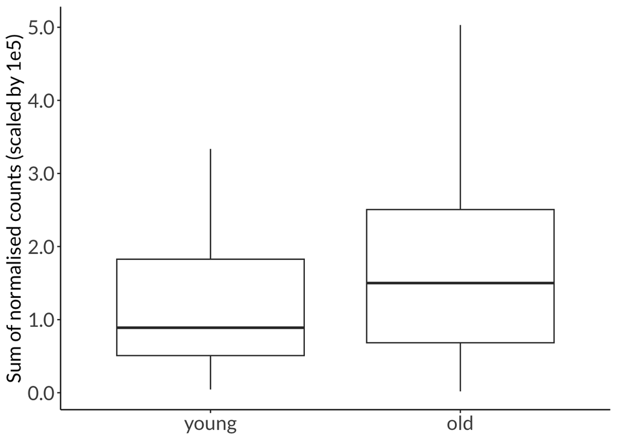

```
    Wilcoxon rank sum exact test

data:  df1$sum and df2$sum
W = 206, p-value = 0.2047
alternative hypothesis: true location shift is not equal to 0
```

```
[1] "Number of chaperones"
```

```
[1] 46  3
```

## [7]

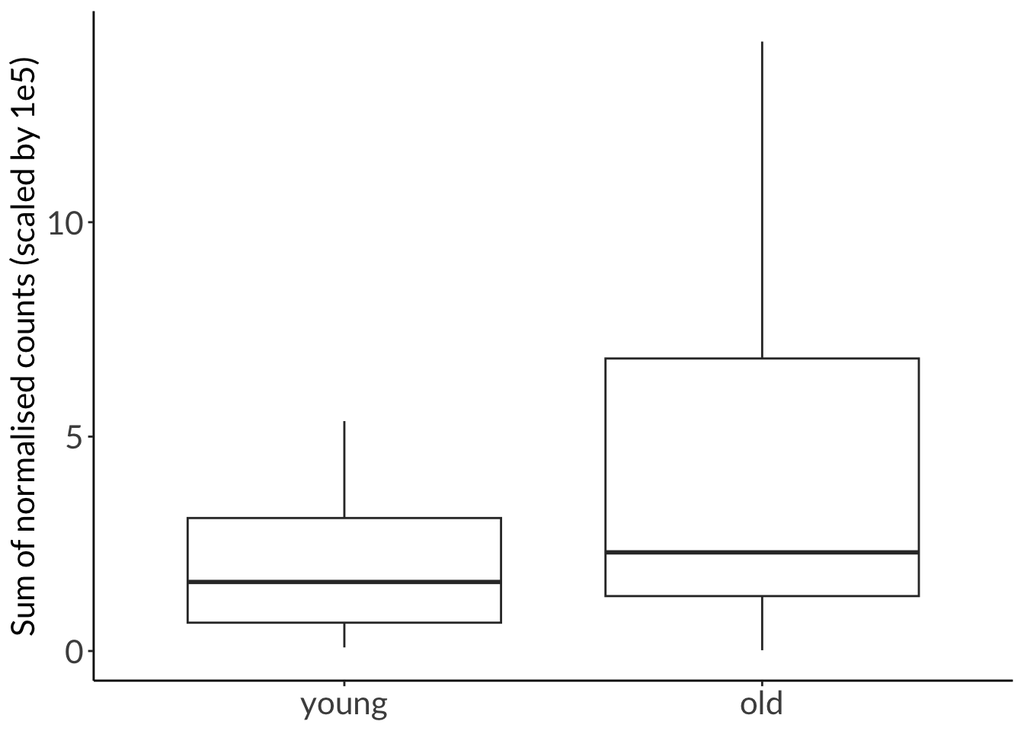

```
    Wilcoxon rank sum exact test

data:  df1$sum and df2$sum
W = 494, p-value = 0.1667
alternative hypothesis: true location shift is not equal to 0
```

```
[1] "Number of chaperones"
```

```
[1] 70  3
```

## [1263]

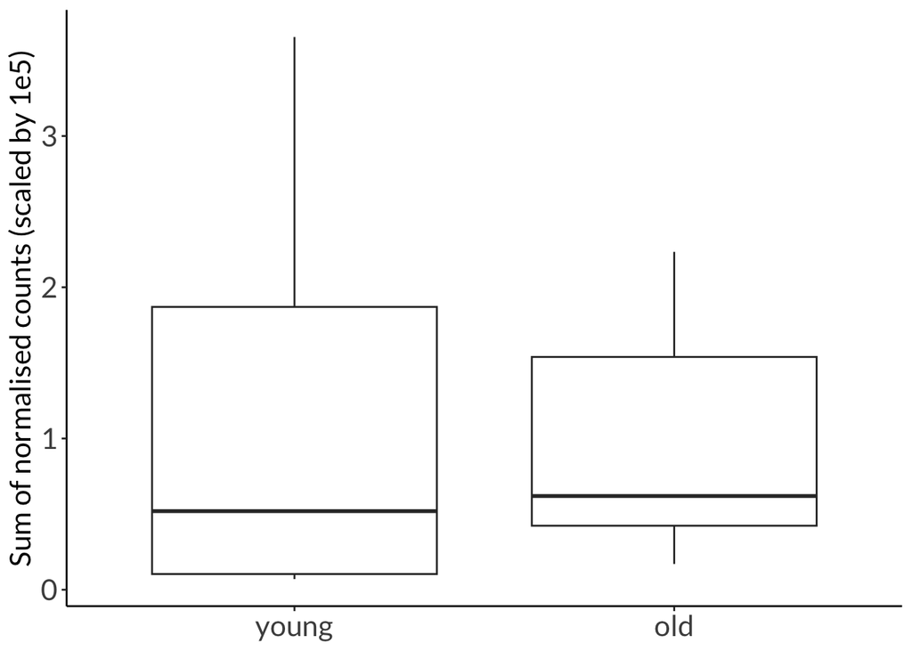

```
    Wilcoxon rank sum exact test

data:  df1$sum and df2$sum
W = 94, p-value = 0.461
alternative hypothesis: true location shift is not equal to 0
```

```
[1] "Number of chaperones"
```

```
[1] 30  3
```

## [4]

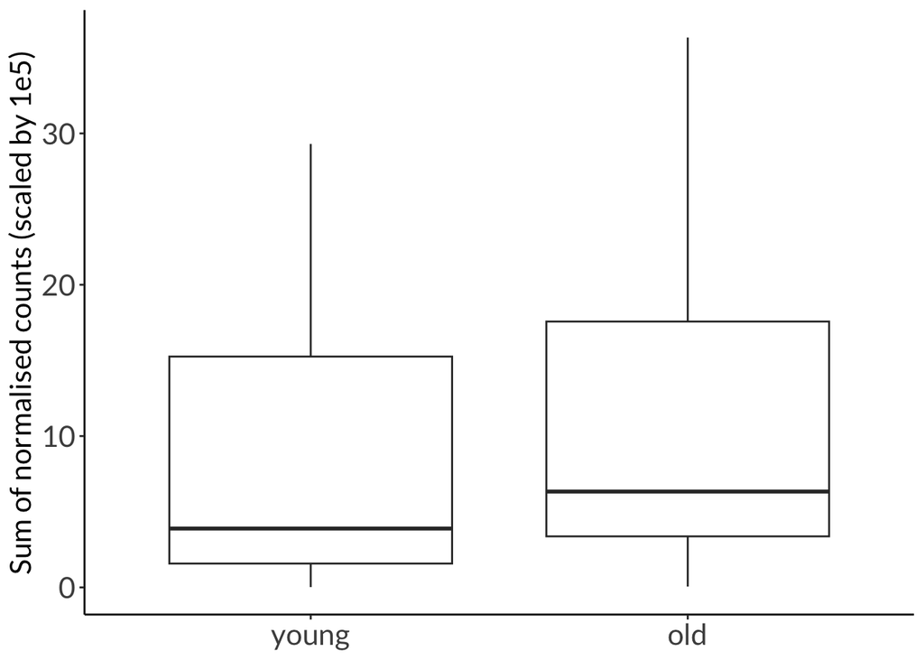

```
    Wilcoxon rank sum exact test

data:  df1$sum and df2$sum
W = 780, p-value = 0.2148
alternative hypothesis: true location shift is not equal to 0
```

```
[1] "Number of chaperones"
```

```
[1] 86  3
```

## [28]

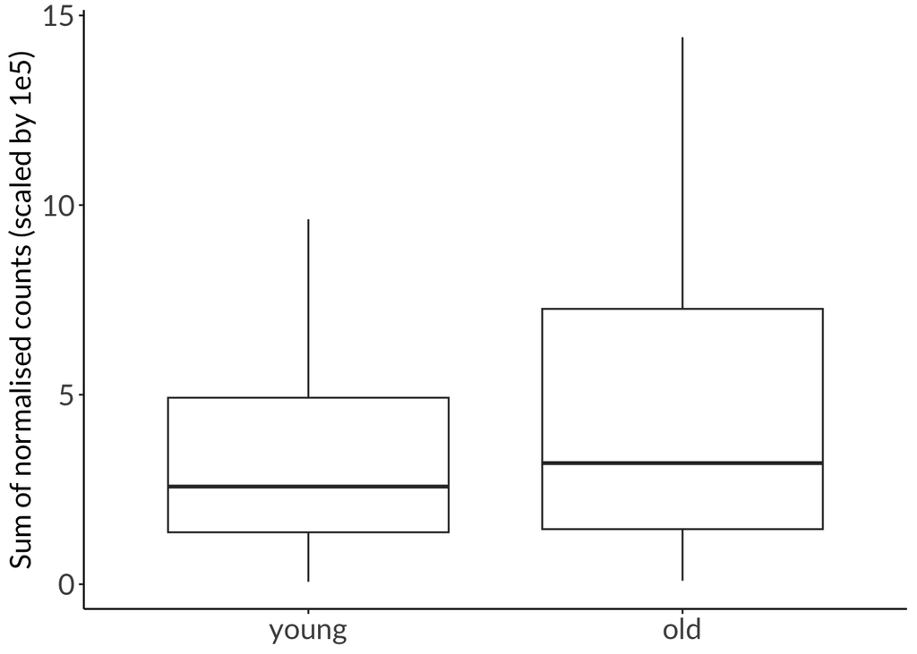

```
    Wilcoxon rank sum exact test

data:  df1$sum and df2$sum
W = 583, p-value = 0.4699
alternative hypothesis: true location shift is not equal to 0
```

```
[1] "Number of chaperones"
```

```
[1] 72  3
```